**Trial biostatistics toolkit**

OperationsBiostatisticsFull library

# TRIALMON: safety screening snapshot

A read-only snapshot of the console at the Cohort 4 data cut (synthetic data)

Computed from the synthetic CSVs in `trialmon_shiny/data/` by `R/logic.R`. Every level rolls up worst-of, watch included. The interactive version is the Shiny console; the rules are explained in the guide; the committee view is the SRC packet. The screen flags; the medical monitor and the committee decide.

Overall (worst-of)

RED

Participants and cohorts

RED

Study tier

AMBER

RED flags

5

AMBER flags

7

Watch

2

Dosed participants

18

Confirmed DLTs (+ pending)

2 (+1)

### Worklist (RED, then AMBER, then watch)

| Level | Tier | Participant, cohort or indicator | Screen | Value |
| --- | --- | --- | --- | --- |
| RED | Participant | CP101-014 | Potential Hy’s Law | AT 4.4x ULN on Day 15; TBL 3.1x ULN on Day 22; ALP 1.1x ULN then; R 4.0 (mixed); peak AT 5.6x ULN |
| RED | Participant | CP101-014 | FDA (2009) discontinuation consideration | ALT or AST > 3x ULN with TBL > 2x ULN in the same draw |
| RED | Participant | CP101-014 | Serious adverse event | Hyperbilirubinaemia |
| RED | Participant | CP101-018 | QTcF (ICH E14 categories) | 503 ms on Day 22 (baseline 462; change 41 ms) |
| RED | Cohort | C4 (120 mg) | DLT tally against 3+3 (rule reference) | 1 of 6 confirmed, 1 pending adjudication. If not a DLT: 1 of 6, escalation-eligible under the rule. If a DLT: 2 of 6, under the rule, the dose exceeds the MTD |
| AMBER | Participant | CP101-004 | Aminotransferase > 3x ULN: confirm | AT 3.3x ULN on Day 22, TBL peak 2.4x ULN; first repeat on Day 24 (2 days later; AT 2.6x ULN) |
| AMBER | Participant | CP101-006 | QTcF (ICH E14 categories) | 486 ms on Day 15 (baseline 453; change 33 ms) |
| AMBER | Participant | CP101-008 | Lab grade 3 or higher | Thrombocytopenia grade 3 (baseline grade 0) |
| AMBER | Participant | CP101-009 | Aminotransferase > 3x ULN: confirm | AT 4.2x ULN on Day 15, TBL peak 1.6x ULN; first repeat on Day 20 (5 days later; AT 3.4x ULN) |
| AMBER | Study | ENROLL | Enrollment versus plan | -22 % vs plan: 18 dosed against 23 planned by this date |
| AMBER | Study | QRY-AGE | Open queries older than 30 days | 14 queries: backlog rising ahead of the C4 data cut |
| AMBER | Study | SF-RATE | Screen-failure rate | 30.8 %: 8 of 26 screened did not meet eligibility (plan: 25%) |
| watch | Participant | CP101-011 | QTcF (ICH E14 categories) | 474 ms on Day 22 (baseline 448; change 26 ms) |
| watch | Participant | CP101-012 | QTcF (ICH E14 categories) | 468 ms on Day 15 (baseline 446; change 22 ms) |

### eDISH

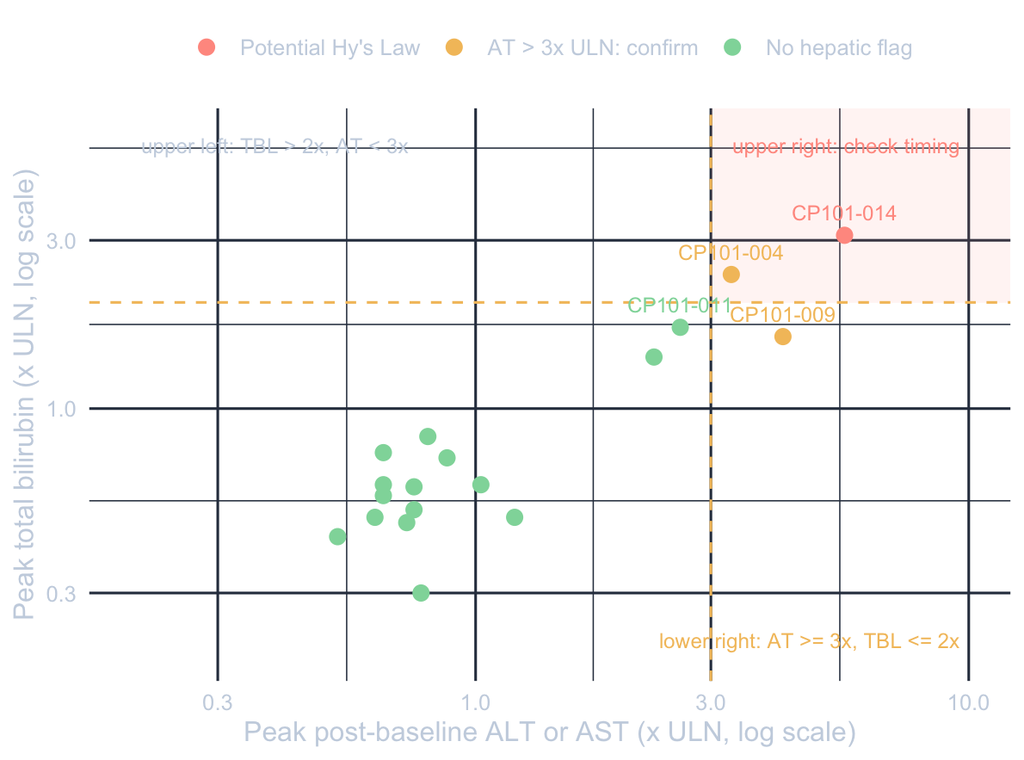

Peaks need not be concurrent; the upper-right quadrant is a prompt to check timing. Potential Hy’s Law (RED) requires TBL above 2x ULN on or after an aminotransferase elevation (ALT or AST at least 3x ULN) within 30 days of it; every such draw opens its own window.

### Dose escalation (rule reference only)

| Cohort | Dose (mg) | Dosed | DLTs | Pending | Level |
| --- | --- | --- | --- | --- | --- |
| C1 | 10 | 3 | 0 | 0 | GREEN |
| C2 | 30 | 3 | 0 | 0 | GREEN |
| C3 | 60 | 6 | 1 | 0 | GREEN |
| C4 | 120 | 6 | 1 | 1 | RED |
| C5 | 200 | 0 | 0 | 0 | GREEN |

Illustrative 3+3 reference: 1 of 3 means expand to 6; 1 of 6 is escalation-eligible; 2 or more means the dose exceeds the MTD. Cohort 4 depends on the pending adjudication of CP101-018. The committee decides.

### Study tier

| Indicator | Value | Level |
| --- | --- | --- |
| Participants with a treatment-emergent SAE (trial-level acceptable range) | 5.6 % of dosed | GREEN |
| Scheduled safety-lab visits with no labs | 0.7 % of visits | GREEN |
| Screen-failure rate | 30.8 % | AMBER |
| Enrollment versus plan | -22 % vs plan | AMBER |
| Open queries older than 30 days | 14 queries | AMBER |
| Important protocol deviations per dosed participant | 0.11 per participant | GREEN |
| Median days from visit to data entry | 2 days | GREEN |

Pre-specified ranges; exceeding one triggers evaluation, not an automatic stop. Operational values are synthetic.

### Adverse events by SOC (participants)

| System organ class | C1 (N=3) | C2 (N=3) | C3 (N=6) | C4 (N=6) | Total (N=18) |
| --- | --- | --- | --- | --- | --- |
| Any TEAE | 2 (67%) | 3 (100%) | 6 (100%) | 6 (100%) | 17 (94%) |
| Investigations | 0 (0%) | 2 (67%) | 2 (33%) | 3 (50%) | 7 (39%) |
| Gastrointestinal disorders | 1 (33%) | 1 (33%) | 2 (33%) | 2 (33%) | 6 (33%) |
| Nervous system disorders | 1 (33%) | 1 (33%) | 1 (17%) | 3 (50%) | 6 (33%) |
| General disorders and administration site conditions | 0 (0%) | 0 (0%) | 1 (17%) | 1 (17%) | 2 (11%) |
| Blood and lymphatic system disorders | 0 (0%) | 0 (0%) | 1 (17%) | 0 (0%) | 1 (6%) |
| Hepatobiliary disorders | 0 (0%) | 0 (0%) | 0 (0%) | 1 (17%) | 1 (6%) |

MedDRA v29.1 (primary SOC); treatment-emergent AEs; participants counted once per row. AE grades as recorded by the investigator (NCI CTCAE v6.0); lab grades elsewhere in TRIALMON: NCI CTCAE v6.0.